# Praticing Statistical Analysis & Machine Learning Techniques- Cancellation Risks in Insurance Contracts-Part 2

Checking correlation for all numeric variables (only) against target variable

```r
correlation_table(data = df1,str_target = "target")
```

```
##                 Variable target
## 1                 target   1.00
## 2            CTCO_NB_SIM   0.32
## 3         ENT_ANCIENNETE   0.22
## 4             CTCO_NB_FM   0.18
## 5     CTCO_NB_TELENTRANT   0.18
## 6              ADH_DUREE   0.14
## 7     CTCO_NB_TELSORTANT   0.12
## 8              AGE_MOYEN   0.09
## 9           AFF_FM_NBSAL   0.06
## 10               CGAFM_N   0.02
## 11     CTCO_DELAI_HORSFM   0.00
## 12        CTCO_NB_VISITE  -0.03
## 13             PRESTFM_N  -0.04
## 14         CTAD_NB_INAFM  -0.07
```

[output cut: 17 more lines]

# Tree decision ( without k-fold Cross_validation)

Splitting train&test set

```r
# split tree
split=0.8
traininex<-createDataPartition(df1$target,p=split,list = FALSE)
trainset<-df1[traininex,]
testset<-df1[-traininex,]
```

Checking dimensions

```r
dim(trainset)
```

```
## [1] 147722     41
```

```r
dim(testset)
```

```
## [1] 36930    41
```

1st attempt with a Tree model ( by using rpart package and no particular data preprocessing)

```r
# fit the model
set.seed(2411)
modeltree<-rpart(target~., data = trainset, method= "class",control=rpart.control(minsplit = 100,minbucket = 20, maxdepth = 10,cp=0.001))
# make predictions
x_test <- testset[,1:40]
y_test <- testset[,41]
predictions <- predict(modeltree, x_test, type = 'class')
# summarize results
confusionMatrix(predictions, y_test)
```

```
## Confusion Matrix and Statistics
##
##           Reference
## Prediction     0     1
##          0 33328  2244
##          1   220  1138
##
##                Accuracy : 0.9333
##                  95% CI : (0.9307, 0.9358)
##     No Information Rate : 0.9084
##     P-Value [Acc > NIR] : < 2.2e-16
##
##                   Kappa : 0.4514
##  Mcnemar's Test P-Value : < 2.2e-16
##
##             Sensitivity : 0.9934
##             Specificity : 0.3365
##          Pos Pred Value : 0.9369
##          Neg Pred Value : 0.8380
##              Prevalence : 0.9084
##          Detection Rate : 0.9025
##    Detection Prevalence : 0.9632
##       Balanced Accuracy : 0.6650
##
##        'Positive' Class : 0
##
```

Note: good accuracy (0.93) but poor specificity rate (0.33). Note: we are interested in the model ‘s specificity rate = TP/(TP+FN); since it reflete the accuracy of the model regarding the class’ 1 = résiliés’.

Let’s visualising the tree and parameters: complexity parameter(cp) and size of tree

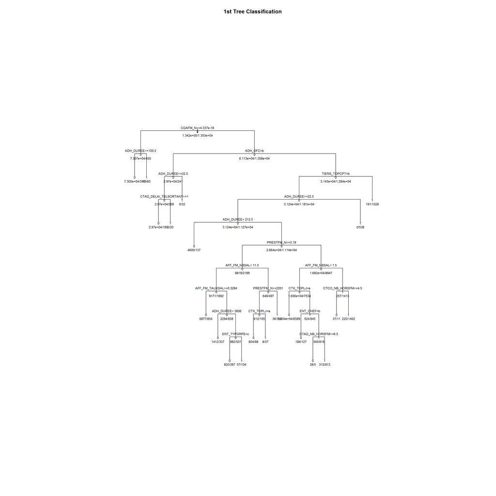

```r
plot(modeltree, uniform=TRUE,
     main="1st Tree Classification ", margin=0.4)
text(modeltree, use.n=TRUE, all=TRUE, cex=.7)
```

Checking the cp number

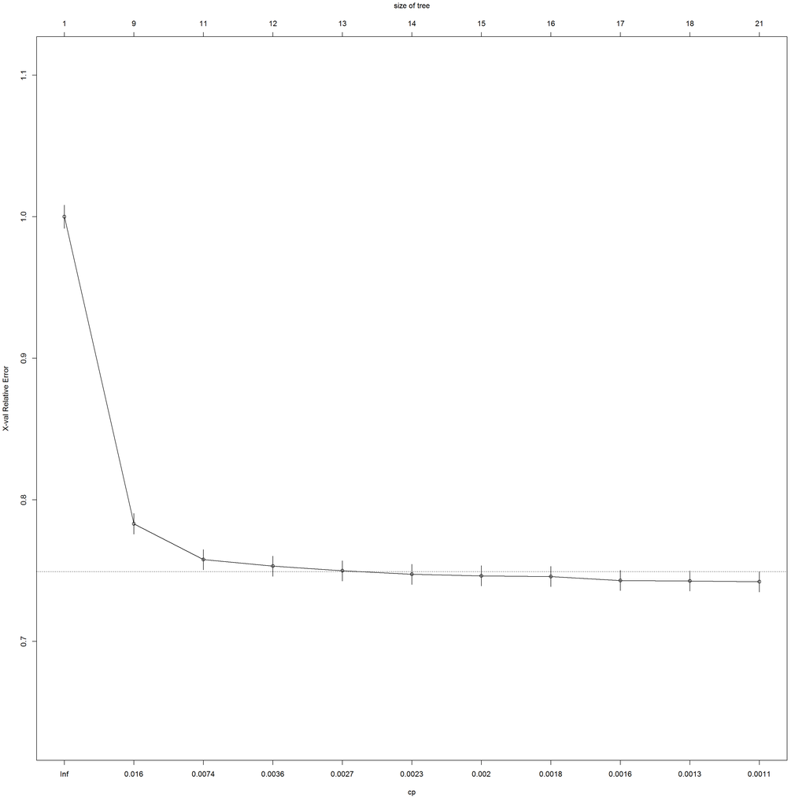

```r
plotcp(modeltree)
```

```r
printcp(modeltree)
```

```
##
## Classification tree:
## rpart(formula = target ~ ., data = trainset, method = "class",
##     control = rpart.control(minsplit = 100, minbucket = 20, maxdepth = 10,
##         cp = 0.001))
##
## Variables actually used in tree construction:
##  [1] ADH_DUREE             ADH_OFC               AFF_FM_NBSAL
##  [4] AFF_FM_TAUXSAL        CGAFM_N               CTAD_DELAI_TELSORTANT
##  [7] CTAD_NB_HORSFM        CTCO_NB_HORSFM        CTX_TOPLJ
## [10] ENT_CHEF              ENT_TYPGRPE           PRESTFM_N
## [13] TIERS_TOPCPT
##
## Root node error: 13530/147722 = 0.091591
##
## n= 147722
##
##           CP nsplit rel error  xerror      xstd
## 1  0.0206208      0   1.00000 1.00000 0.0081939
## 2  0.0131559      8   0.78182 0.78307 0.0073298
## 3  0.0042129     10   0.75551 0.75780 0.0072195
## 4  0.0031042     11   0.75129 0.75322 0.0071993
## 5  0.0023651     12   0.74819 0.74989 0.0071845
## 6  0.0021434     13   0.74582 0.74745 0.0071737
## 7  0.0019217     14   0.74368 0.74642 0.0071691
## 8  0.0016999     15   0.74176 0.74590 0.0071668
## 9  0.0014782     16   0.74006 0.74309 0.0071543
## 10 0.0011579     17   0.73858 0.74279 0.0071530
## 11 0.0010000     20   0.73511 0.74220 0.0071503
```

2nd attempt with a Tree model: increasing the maximum node of the tree and decreasing the cp value

```r
# fit the 2nd tree model
set.seed(1412)
modeltree1<-rpart(target~., data = trainset, method= "class",control=rpart.control(minsplit = 50,minbucket = 20, maxdepth = 20,cp=0.0005))
#make predictions
set.seed(0712)
predictions1 <- predict(modeltree1, x_test, type = 'class')
# summarize results
confusionMatrix(predictions1, y_test)
```

```
## Confusion Matrix and Statistics
##
##           Reference
## Prediction     0     1
##          0 33126  1855
##          1   422  1527
##
##                Accuracy : 0.9383
##                  95% CI : (0.9358, 0.9408)
##     No Information Rate : 0.9084
##     P-Value [Acc > NIR] : < 2.2e-16
##
##                   Kappa : 0.5422
##  Mcnemar's Test P-Value : < 2.2e-16
##
##             Sensitivity : 0.9874
##             Specificity : 0.4515
##          Pos Pred Value : 0.9470
##          Neg Pred Value : 0.7835
##              Prevalence : 0.9084
##          Detection Rate : 0.8970
##    Detection Prevalence : 0.9472
##       Balanced Accuracy : 0.7195
##
##        'Positive' Class : 0
##
```

We have just got a little better score ( 0.94 for accuracy & 0.45 for specificity) with a deeper tree having a small ‘cp’ value

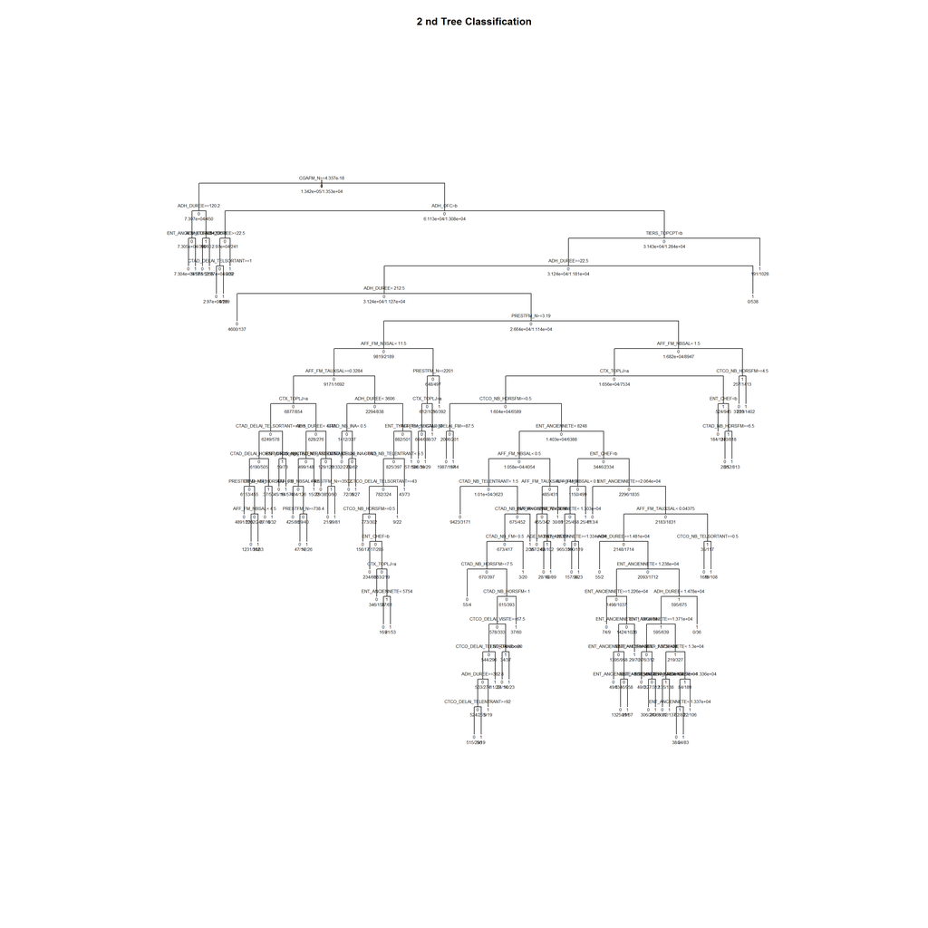

```r
plot(modeltree1, uniform=TRUE,
     main="2 nd Tree Classification", margin=0.2)
text(modeltree1, use.n=TRUE, all=TRUE, cex=.5)
```

Checking Cp and prediction results again

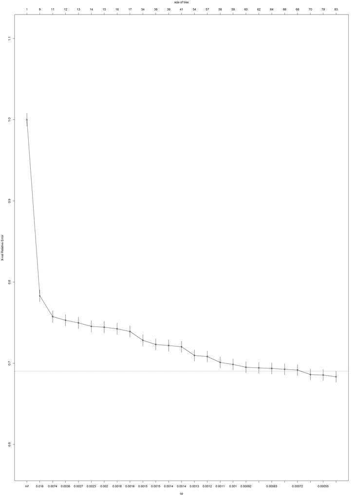

```r
plotcp(modeltree1)
```

```r
printcp(modeltree1)
```

```
##
## Classification tree:
## rpart(formula = target ~ ., data = trainset, method = "class",
##     control = rpart.control(minsplit = 50, minbucket = 20, maxdepth = 20,
##         cp = 5e-04))
##
## Variables actually used in tree construction:
##  [1] ADH_DUREE             ADH_OFC               AFF_FM_NBSAL
##  [4] AFF_FM_TAUXSAL        AGE_MOYEN             CGAFM_N
##  [7] CTAD_DELAI_FM         CTAD_DELAI_HORSFM     CTAD_DELAI_INA
## [10] CTAD_DELAI_TELSORTANT CTAD_NB_FM            CTAD_NB_HORSFM
## [13] CTAD_NB_INA           CTAD_NB_INAFM         CTAD_NB_TELENTRANT
## [16] CTCO_DELAI_TELENTRANT CTCO_DELAI_TELSORTANT CTCO_DELAI_VISITE
## [19] CTCO_NB_HORSFM        CTCO_NB_TELENTRANT    CTCO_NB_TELSORTANT
## [22] CTX_TOPLJ             ENT_ANCIENNETE        ENT_CHEF
```

[output cut: 33 more lines]

Now, let’s try to improve our tree model with pruning practice

We’re prunning the tree using the best cp

```r
# getting the best cp.
bestcp <- modeltree1$cptable[which.min(modeltree1$cptable[,"xerror"]),"CP"]
bestcp
```

```
## [1] 5e-04
```

```r
# pruning the tree with the best cp
set.seed(3004)
tree.pruned <- prune(modeltree1, cp = bestcp,surrogatestyle=1)
```

Making predictions with the pruned tree

```r
predictprune<- predict(tree.pruned,x_test,type="class")
# and check the result by confusion matrix
confusionMatrix(predictprune,y_test)
```

```
## Confusion Matrix and Statistics
##
##           Reference
## Prediction     0     1
##          0 33126  1855
##          1   422  1527
##
##                Accuracy : 0.9383
##                  95% CI : (0.9358, 0.9408)
##     No Information Rate : 0.9084
##     P-Value [Acc > NIR] : < 2.2e-16
##
##                   Kappa : 0.5422
##  Mcnemar's Test P-Value : < 2.2e-16
##
##             Sensitivity : 0.9874
##             Specificity : 0.4515
##          Pos Pred Value : 0.9470
##          Neg Pred Value : 0.7835
##              Prevalence : 0.9084
##          Detection Rate : 0.8970
##    Detection Prevalence : 0.9472
##       Balanced Accuracy : 0.7195
##
##        'Positive' Class : 0
##
```

Note: No better specificty rate with the pruned tree.

By default, the threshold the model use to predict is fixed at 0.5. Tuning this parameter might be a good solution for obtaining a better specificity rate.

```r
# making output class by probability mesure
predictpruneprob<-predict(tree.pruned,x_test,type="prob")
# fix the threshold at 0.3
predictionstreeprob<- ifelse(predictpruneprob[,2] >=0.3,1,0)
head(predictionstreeprob,2)
```

```
##  4 12
##  1  0
```

```r
confusionMatrix(predictionstreeprob,y_test)
```

```
## Confusion Matrix and Statistics
##
##           Reference
## Prediction     0     1
##          0 32212  1352
##          1  1336  2030
##
##                Accuracy : 0.9272
##                  95% CI : (0.9245, 0.9298)
##     No Information Rate : 0.9084
##     P-Value [Acc > NIR] : <2e-16
##
##                   Kappa : 0.5616
##  Mcnemar's Test P-Value : 0.7723
##
##             Sensitivity : 0.9602
##             Specificity : 0.6002
##          Pos Pred Value : 0.9597
##          Neg Pred Value : 0.6031
##              Prevalence : 0.9084
##          Detection Rate : 0.8722
##    Detection Prevalence : 0.9089
##       Balanced Accuracy : 0.7802
##
##        'Positive' Class : 0
##
```

Let’s take a look now at a curve showing Sensitivity vs. Specificity evolution

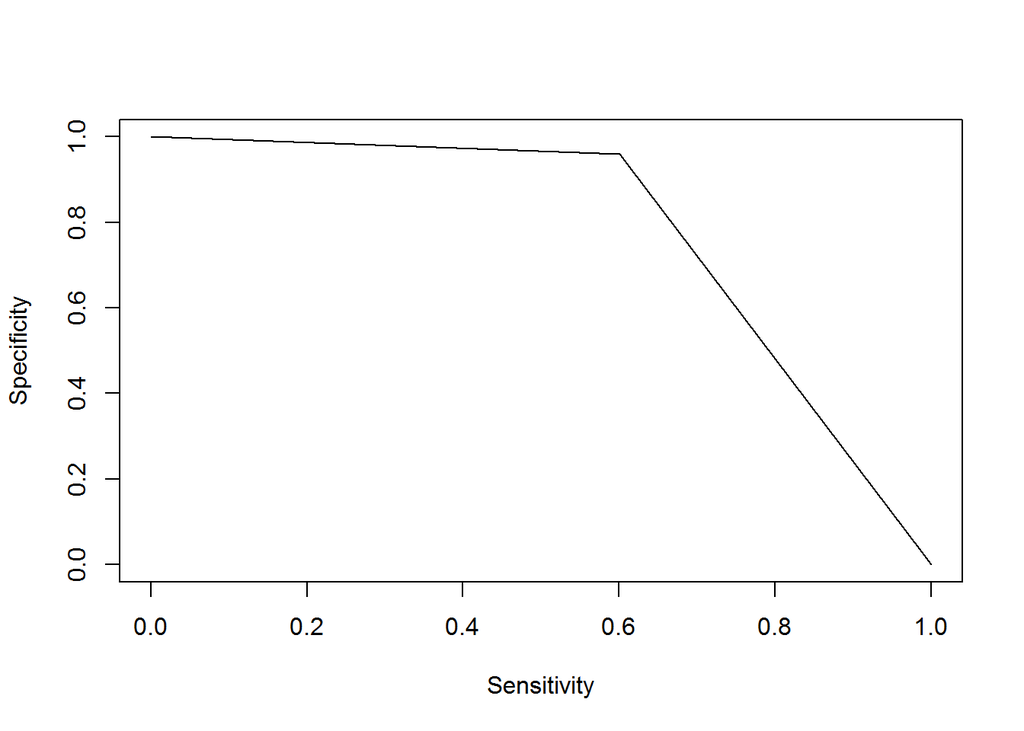

```r
performanceTree<-prediction(predictionstreeprob,y_test)
performanceTree<-performance(performanceTree, measure = "spec",x.measure = "sens")
plot(performanceTree)
```

# Handling with data ( more)

Checking for missing values and look how many unique values there are for each variable

```r
df2<-df1
sapply(df2,function(x) sum(is.na(x)))
```

```
##           ENT_TYPGRPE                ENT_DR        ENT_ANCIENNETE
##                     0                     0                     0
##        ENT_TOPTELPORT           ENT_TOPMAIL              ENT_CHEF
##                     0                     0                     0
##          TIERS_TOPCPT            CTAD_NB_FM         CTAD_DELAI_FM
##                     0                     0                171181
##            CTCO_NB_FM         CTCO_DELAI_FM        CTAD_NB_HORSFM
##                     0                161925                     0
##     CTAD_DELAI_HORSFM        CTCO_NB_HORSFM     CTCO_DELAI_HORSFM
##                146653                     0                148789
##           CTAD_NB_INA        CTAD_DELAI_INA         CTAD_NB_INAFM
##                     0                167444                     0
##      CTAD_DELAI_INAFM        CTCO_NB_VISITE     CTCO_DELAI_VISITE
##                180858                     0                129553
##           CTCO_NB_SIM        CTCO_DELAI_SIM    CTAD_NB_TELENTRANT
##                     0                174325                     0
##    CTAD_NB_TELSORTANT CTAD_DELAI_TELSORTANT    CTCO_NB_TELENTRANT
##                     0                159109                     0
## CTCO_DELAI_TELENTRANT    CTCO_NB_TELSORTANT CTCO_DELAI_TELSORTANT
##                150242                     0                 88637
##             CTX_TOPLJ             CTX_TOPRJ             PRESTFM_N
##                     0                     0                     0
##               CGAFM_N             AGE_MOYEN             ADH_DUREE
##                     0                     0                     0
##               ADH_OFC          AFF_FM_NBSAL        AFF_FM_TAUXSAL
##                     0                     0                     0
##                ADIFUE                target
##                     0                     0
```

Imputing 0 au Na’s values; make sure that there is one missing value for a time variable ( délai) when the value of the number variable ( nombre) is equal to zero

```r
df2[is.na(df2)]<-0
df_status(df2)
```

```
##                 variable q_zeros p_zeros q_na p_na q_inf p_inf    type
## 1            ENT_TYPGRPE       0    0.00    0    0     0     0  factor
## 2                 ENT_DR       0    0.00    0    0     0     0  factor
## 3         ENT_ANCIENNETE       0    0.00    0    0     0     0 numeric
## 4         ENT_TOPTELPORT   78882   42.72    0    0     0     0  factor
## 5            ENT_TOPMAIL   37183   20.14    0    0     0     0  factor
## 6               ENT_CHEF  115899   62.77    0    0     0     0  factor
## 7           TIERS_TOPCPT    2234    1.21    0    0     0     0  factor
## 8             CTAD_NB_FM  171181   92.70    0    0     0     0 numeric
## 9          CTAD_DELAI_FM  171298   92.77    0    0     0     0 numeric
## 10            CTCO_NB_FM  161925   87.69    0    0     0     0 numeric
## 11         CTCO_DELAI_FM  161947   87.70    0    0     0     0 numeric
## 12        CTAD_NB_HORSFM  146653   79.42    0    0     0     0 numeric
## 13     CTAD_DELAI_HORSFM  146855   79.53    0    0     0     0 numeric
## 14        CTCO_NB_HORSFM  148789   80.58    0    0     0     0 numeric
```

[output cut: 69 more lines]

```r
#write.csv(df2,"C:/Users/PB00193/Desktop/Project Resil/medical cost1/df2.csv")
```

# Tree with K-fold Cross-validation

Let’s make k-fold CV with the package ‘caret’

```r
train_control <- trainControl(method="repeatedcv", number=10, repeats=3)
```

Now, let’s split the data and fit a model

```r
set.seed(2014)
split=0.8
traininex1<-createDataPartition(df2$target,p=split,list = FALSE)
trainset1<-df2[traininex1,]
testset1<-df2[-traininex1,]
```

And fit a Tree model with train test et test set

```r
modeltreecv1 <- train(target~., data=trainset1, trControl=train_control, method="rpart")
predictionstreecv1<- predict(modeltreecv1,testset1[,1:40])
confusionMatrix(predictionstreecv1,testset1[,41])
```

```
## Confusion Matrix and Statistics
##
##           Reference
## Prediction     0     1
##          0 33286  2363
##          1   262  1019
##
##                Accuracy : 0.9289
##                  95% CI : (0.9263, 0.9315)
##     No Information Rate : 0.9084
##     P-Value [Acc > NIR] : < 2.2e-16
##
##                   Kappa : 0.4072
##  Mcnemar's Test P-Value : < 2.2e-16
##
##             Sensitivity : 0.9922
##             Specificity : 0.3013
##          Pos Pred Value : 0.9337
##          Neg Pred Value : 0.7955
##              Prevalence : 0.9084
##          Detection Rate : 0.9013
##    Detection Prevalence : 0.9653
##       Balanced Accuracy : 0.6467
##
##        'Positive' Class : 0
##
```

No good specificity rate

- Specificity rate has been not improved by k-fold cross-validation technique

# Bagging , Random Forest & Boosting

- Fistly, we are going to apply Bagging technique in order to perform tree based models

```r
set.seed(2411)
library(ipred)
modelbagging<- bagging(target~ .,data = trainset1)
predictions.bag <- predict(modelbagging, testset1[,1:40], type="class")
#saving this model
#saveRDS(fit,"E:/Project Resil/medi 1/baggingmodel.rds")
#loading the model
#modelbagging<-readRDS("E:/Project Resil/medi 1/baggingmodel.rds")
#make a new prediction on new data using this bagging model
#newpredict<-predict(modelbagging,newdatatest[,:])
#confusionMatrix(...)
```

Checking accuracy metrics

```r
confusionMatrix(predictions.bag,testset1$target)
```

```
## Confusion Matrix and Statistics
##
##           Reference
## Prediction     0     1
##          0 33100  1558
##          1   448  1824
##
##                Accuracy : 0.9457
##                  95% CI : (0.9433, 0.948)
##     No Information Rate : 0.9084
##     P-Value [Acc > NIR] : < 2.2e-16
##
##                   Kappa : 0.617
##  Mcnemar's Test P-Value : < 2.2e-16
##
##             Sensitivity : 0.9866
##             Specificity : 0.5393
##          Pos Pred Value : 0.9550
##          Neg Pred Value : 0.8028
##              Prevalence : 0.9084
##          Detection Rate : 0.8963
##    Detection Prevalence : 0.9385
##       Balanced Accuracy : 0.7630
##
##        'Positive' Class : 0
##
```

Note: we have got a good accuracy and a small improvement in temrs of specificity rate but that’s stil not satisfying.

Let’s set the threshold at 0.3

```r
predictions.bagprob <- predict(modelbagging, testset1[,1:40], type="prob")
head(predictions.bagprob,2)
```

```
##         0    1
## [1,] 0.68 0.32
## [2,] 1.00 0.00
```

```r
predictions.bagprob<- ifelse(predictions.bagprob[,2] >=0.3,1,0)
confusionMatrix(predictions.bagprob,testset1$target)
```

```
## Confusion Matrix and Statistics
##
##           Reference
## Prediction     0     1
##          0 32419  1047
##          1  1129  2335
##
##                Accuracy : 0.9411
##                  95% CI : (0.9386, 0.9435)
##     No Information Rate : 0.9084
##     P-Value [Acc > NIR] : < 2e-16
##
##                   Kappa : 0.6497
##  Mcnemar's Test P-Value : 0.08249
##
##             Sensitivity : 0.9663
##             Specificity : 0.6904
##          Pos Pred Value : 0.9687
##          Neg Pred Value : 0.6741
##              Prevalence : 0.9084
##          Detection Rate : 0.8778
##    Detection Prevalence : 0.9062
##       Balanced Accuracy : 0.8284
##
##        'Positive' Class : 0
##
```

Sensitivity vs. Specificity by ROC plot ( Bagging model)

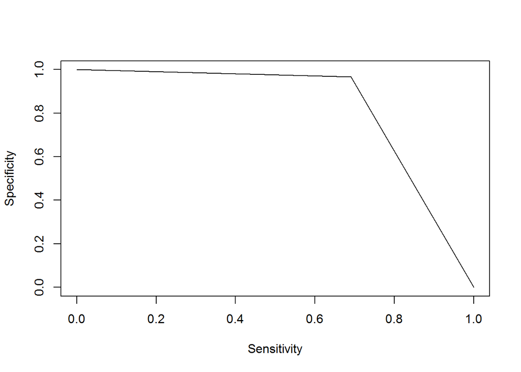

```r
library(ROCR)
performanceBag<-prediction(predictions.bagprob,testset1$target)
performanceBag<-performance(performanceBag, measure = "spec",x.measure = "sens")
plot(performanceBag)
```

- Random Forest

```r
library(randomForest)
# fit the model
modelRF<- randomForest(target~ ., data = trainset1, mtry=8, ntree=500,importance=TRUE, type='Classification')
modelRF
```

```
##
## Call:
##  randomForest(formula = target ~ ., data = trainset1, mtry = 8,      ntree = 500, importance = TRUE, type = "Classification")
##                Type of random forest: classification
##                      Number of trees: 500
## No. of variables tried at each split: 8
##
##         OOB estimate of  error rate: 5.86%
## Confusion matrix:
##        0    1 class.error
## 0 132982 1210 0.009016931
## 1   7451 6079 0.550702143
```

```r
#saveRDS(modelRF,"E:/Project Resil/medi 1/RFmodel.rds")
# make predictions
predictionsRF<- predict(modelRF,newdata= testset1)
confusionMatrix(predictionsRF,testset1$target)
```

```
## Confusion Matrix and Statistics
##
##           Reference
## Prediction     0     1
##          0 33254  1841
##          1   294  1541
##
##                Accuracy : 0.9422
##                  95% CI : (0.9398, 0.9445)
##     No Information Rate : 0.9084
##     P-Value [Acc > NIR] : < 2.2e-16
##
##                   Kappa : 0.5626
##  Mcnemar's Test P-Value : < 2.2e-16
##
##             Sensitivity : 0.9912
##             Specificity : 0.4556
##          Pos Pred Value : 0.9475
##          Neg Pred Value : 0.8398
##              Prevalence : 0.9084
##          Detection Rate : 0.9005
##    Detection Prevalence : 0.9503
##       Balanced Accuracy : 0.7234
##
##        'Positive' Class : 0
##
```

Good result for the accuracy (0.94) but not the case for Specificity (0.45)

Checking variable importance

```r
importance(modelRF)
```

```
##                               0           1 MeanDecreaseAccuracy
## ENT_TYPGRPE           30.973630  44.2609038            42.363411
## ENT_DR                38.904927  23.3493251            46.449907
## ENT_ANCIENNETE        47.453703  -8.0463351            51.977929
## ENT_TOPTELPORT        41.499615  -7.6087601            46.491525
## ENT_TOPMAIL           33.996250  -0.9454045            42.002924
## ENT_CHEF              29.999316  46.7791088            59.105877
## TIERS_TOPCPT          87.186825 147.2274467           148.438152
## CTAD_NB_FM            25.489440 -19.1472084            24.083228
## CTAD_DELAI_FM         16.171069 -14.7760596            14.792979
## CTCO_NB_FM             8.791918  10.4189341            10.646671
## CTCO_DELAI_FM          8.369429  17.4049975            11.361064
## CTAD_NB_HORSFM        19.072425  -4.5400478            21.608831
## CTAD_DELAI_HORSFM     18.487804 -12.6719489            17.981229
## CTCO_NB_HORSFM        24.471206 -10.3569000            26.687867
## CTCO_DELAI_HORSFM     27.842414   4.7340080            29.421382
## CTAD_NB_INA           15.500067 -12.0669183            14.264513
## CTAD_DELAI_INA        13.945116  -5.3778332            13.733611
## CTAD_NB_INAFM         18.722263  -4.8497358            18.694403
## CTAD_DELAI_INAFM      15.533828  -7.1426399            15.216175
## CTCO_NB_VISITE        11.066056  -8.0731363            10.666076
## CTCO_DELAI_VISITE      9.221173  20.8966004            10.298363
## CTCO_NB_SIM           11.245126  -3.4085078            11.188725
## CTCO_DELAI_SIM        10.319047  -2.1095120            10.331409
## CTAD_NB_TELENTRANT    84.780617 -47.7740946            88.833002
## CTAD_NB_TELSORTANT    17.437695 -18.7226572            16.078180
## CTAD_DELAI_TELSORTANT 15.147548  -1.1363995            15.180540
## CTCO_NB_TELENTRANT    14.717059 -16.9603697            13.501960
## CTCO_DELAI_TELENTRANT 12.733257 -15.4934532            11.854463
## CTCO_NB_TELSORTANT    18.878744 -16.1582564            18.410859
## CTCO_DELAI_TELSORTANT 16.656982  24.8563918            17.854953
## CTX_TOPLJ             29.053732 167.9082424            79.836072
## CTX_TOPRJ             32.215169  14.9448120            34.229804
## PRESTFM_N             54.261146  55.0443414            62.702415
## CGAFM_N               72.061715 102.6278452           110.258931
## AGE_MOYEN             17.869589 -16.1816006            17.850013
## ADH_DUREE             65.393215  76.5231897            76.637567
## ADH_OFC               17.096819  81.0189331            68.849663
## AFF_FM_NBSAL          38.525050 -28.3244643            39.749036
## AFF_FM_TAUXSAL        49.354084 -27.5370914            48.725667
```

[output cut: 27 more lines]

```
## CTAD_DELAI_TELSORTANT        133.12438
## CTCO_NB_TELENTRANT           102.64058
## CTCO_DELAI_TELENTRANT        183.25881
## CTCO_NB_TELSORTANT           348.40954
## CTCO_DELAI_TELSORTANT        705.24676
## CTX_TOPLJ                    638.52652
## CTX_TOPRJ                     81.83494
## PRESTFM_N                   1651.15489
## CGAFM_N                     1435.70133
## AGE_MOYEN                    492.97974
## ADH_DUREE                   3257.94611
## ADH_OFC                     1046.58229
## AFF_FM_NBSAL                1053.73733
## AFF_FM_TAUXSAL               798.49493
## ADIFUE                        17.60969
```

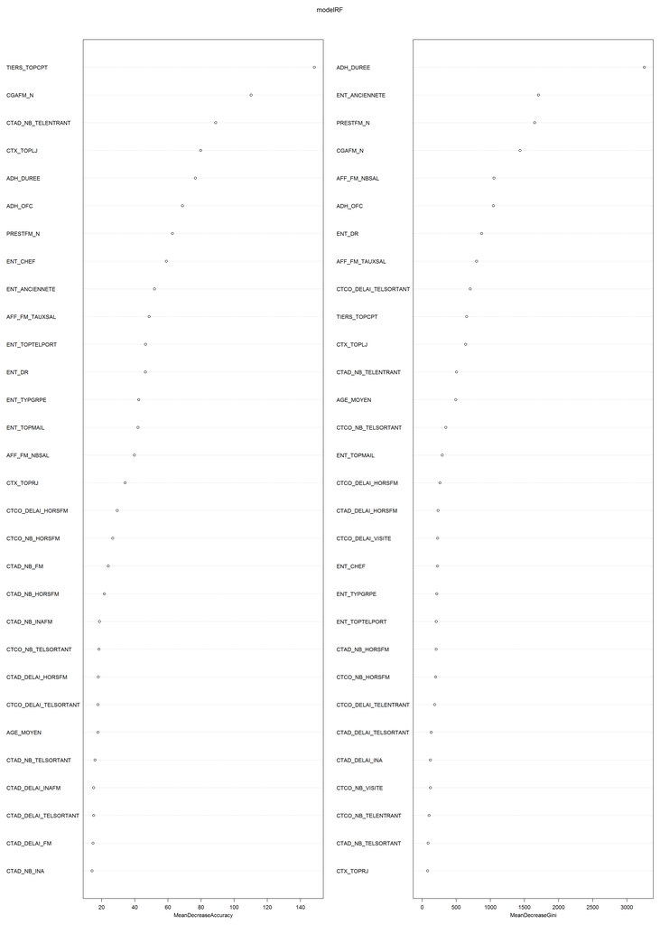

```r
varImpPlot(modelRF)
```

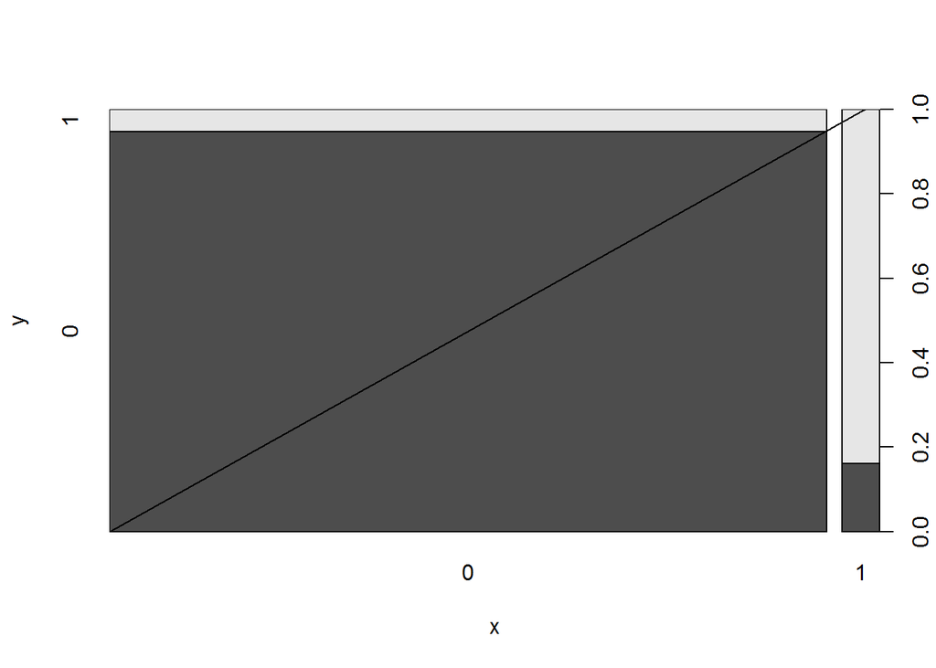

```r
plot(predictionsRF,testset1$target)
abline(0,1)
```

Using the threshold = 0.3

```r
predictionsRFprob<- predict(modelRF,newdata= testset1, type = "prob")
predictionsRFprob<- ifelse(predictionsRFprob[,2] >=0.3,1,0)
confusionMatrix(predictionsRFprob,testset1$target)
```

```
## Confusion Matrix and Statistics
##
##           Reference
## Prediction     0     1
##          0 32685  1323
##          1   863  2059
##
##                Accuracy : 0.9408
##                  95% CI : (0.9384, 0.9432)
##     No Information Rate : 0.9084
##     P-Value [Acc > NIR] : < 2.2e-16
##
##                   Kappa : 0.6211
##  Mcnemar's Test P-Value : < 2.2e-16
##
##             Sensitivity : 0.9743
##             Specificity : 0.6088
##          Pos Pred Value : 0.9611
##          Neg Pred Value : 0.7047
##              Prevalence : 0.9084
##          Detection Rate : 0.8851
##    Detection Prevalence : 0.9209
##       Balanced Accuracy : 0.7915
##
##        'Positive' Class : 0
##
```

Sensitivity vs. Specificity by ROC plot ( Random Forest model)

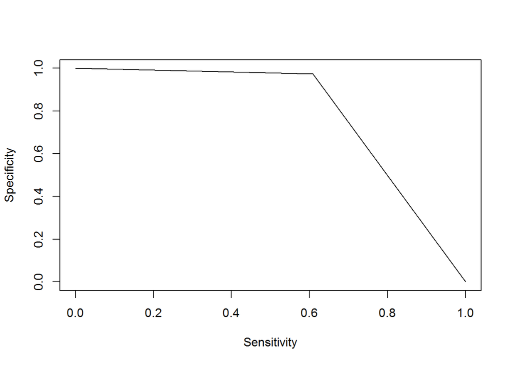

```r
library(ROCR)
performanceRF<-prediction(predictionsRFprob,testset1$target)
performanceRF<-performance(performanceRF, measure = "spec",x.measure = "sens")
plot(performanceRF)
```

- Boosting technique with GBM package

Trying a Gradient Boosting first. We use the distribution ‘bernouilli’ since we have a binary classification problem and apply GB algorithm.

```r
set.seed(1805)
library(gbm)
modelboost<-gbm.fit(x=trainset1[,1:40],y=as.vector(trainset1$target),distribution = "bernoulli", interaction.depth = 5,n.trees =200,train.fraction = 0.5,shrinkage = 0.1,n.minobsinnode = 30)
```

```
##      1        0.6718          0.4750     0.1000    0.0294
##      2        0.6307          0.4516     0.1000    0.0205
##      3        0.5992          0.4337     0.1000    0.0153
##      4        0.5739          0.4173     0.1000    0.0127
##      5        0.5517          0.4023     0.1000    0.0111
##      6        0.5338          0.3912     0.1000    0.0087
##      7        0.5173          0.3806     0.1000    0.0082
##      8        0.5040          0.3708     0.1000    0.0066
##      9        0.4921          0.3615     0.1000    0.0059
##     10        0.4820          0.3545     0.1000    0.0049
##     20        0.4246          0.3158     0.1000    0.0015
##     40        0.3853          0.2826     0.1000    0.0006
##     60        0.3712          0.2721     0.1000    0.0002
##     80        0.3610          0.2680     0.1000    0.0001
##    100        0.3523          0.2627     0.1000    0.0002
##    120        0.3458          0.2614     0.1000    0.0000
##    140        0.3387          0.2633     0.1000    0.0001
##    160        0.3330          0.2595     0.1000    0.0001
##    180        0.3276          0.2558     0.1000    0.0001
##    200        0.3225          0.2573     0.1000    0.0000
```

```r
#saveRDS(modelboost,"E:/Project Resil/medi 1/GBmodel.rds")
```

Finding out the best iteration number and checking relative influence statistics

```r
best.iter <- gbm.perf(modelboost,method="test")
```

[figure not shown]

```r
print(best.iter)
```

```
## [1] 180
```

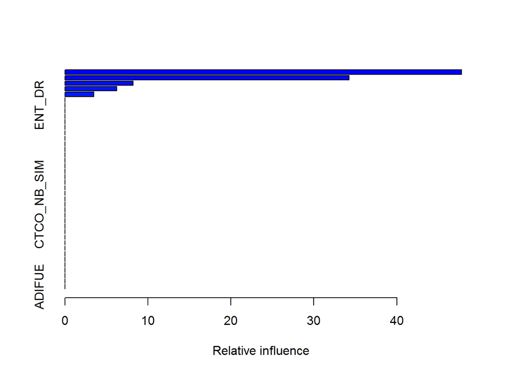

```
##                                         var   rel.inf
## CGAFM_N                             CGAFM_N 47.813505
## ADH_OFC                             ADH_OFC 34.242872
## TIERS_TOPCPT                   TIERS_TOPCPT  8.210390
## CTCO_DELAI_HORSFM         CTCO_DELAI_HORSFM  6.248700
## ADH_DUREE                         ADH_DUREE  3.484533
## ENT_TYPGRPE                     ENT_TYPGRPE  0.000000
## ENT_DR                               ENT_DR  0.000000
## ENT_ANCIENNETE               ENT_ANCIENNETE  0.000000
## ENT_TOPTELPORT               ENT_TOPTELPORT  0.000000
## ENT_TOPMAIL                     ENT_TOPMAIL  0.000000
## ENT_CHEF                           ENT_CHEF  0.000000
## CTAD_NB_FM                       CTAD_NB_FM  0.000000
## CTAD_DELAI_FM                 CTAD_DELAI_FM  0.000000
## CTCO_NB_FM                       CTCO_NB_FM  0.000000
## CTCO_DELAI_FM                 CTCO_DELAI_FM  0.000000
## CTAD_NB_HORSFM               CTAD_NB_HORSFM  0.000000
## CTAD_DELAI_HORSFM         CTAD_DELAI_HORSFM  0.000000
## CTCO_NB_HORSFM               CTCO_NB_HORSFM  0.000000
## CTAD_NB_INA                     CTAD_NB_INA  0.000000
## CTAD_DELAI_INA               CTAD_DELAI_INA  0.000000
## CTAD_NB_INAFM                 CTAD_NB_INAFM  0.000000
## CTAD_DELAI_INAFM           CTAD_DELAI_INAFM  0.000000
## CTCO_NB_VISITE               CTCO_NB_VISITE  0.000000
## CTCO_DELAI_VISITE         CTCO_DELAI_VISITE  0.000000
## CTCO_NB_SIM                     CTCO_NB_SIM  0.000000
## CTCO_DELAI_SIM               CTCO_DELAI_SIM  0.000000
## CTAD_NB_TELENTRANT       CTAD_NB_TELENTRANT  0.000000
## CTAD_NB_TELSORTANT       CTAD_NB_TELSORTANT  0.000000
## CTAD_DELAI_TELSORTANT CTAD_DELAI_TELSORTANT  0.000000
## CTCO_NB_TELENTRANT       CTCO_NB_TELENTRANT  0.000000
## CTCO_DELAI_TELENTRANT CTCO_DELAI_TELENTRANT  0.000000
## CTCO_NB_TELSORTANT       CTCO_NB_TELSORTANT  0.000000
## CTCO_DELAI_TELSORTANT CTCO_DELAI_TELSORTANT  0.000000
## CTX_TOPLJ                         CTX_TOPLJ  0.000000
## CTX_TOPRJ                         CTX_TOPRJ  0.000000
## PRESTFM_N                         PRESTFM_N  0.000000
## AGE_MOYEN                         AGE_MOYEN  0.000000
## AFF_FM_NBSAL                   AFF_FM_NBSAL  0.000000
## AFF_FM_TAUXSAL               AFF_FM_TAUXSAL  0.000000
## ADIFUE                               ADIFUE  0.000000
```

```r
# checking relative influence by using different numbers of trees
summary(modelboost,n.trees=1) # based on the first tree
```

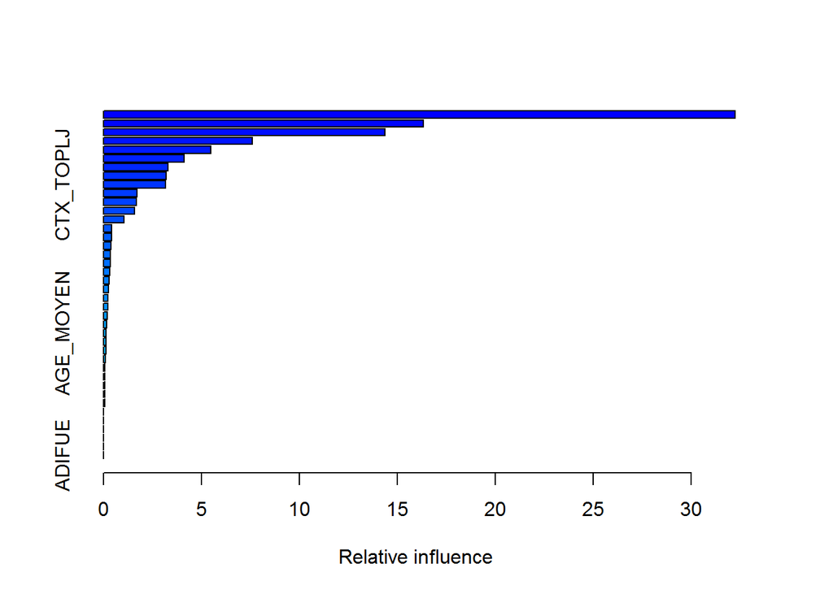

```
##                                         var      rel.inf
## CGAFM_N                             CGAFM_N 32.246078611
## ADH_DUREE                         ADH_DUREE 16.331093848
## ADH_OFC                             ADH_OFC 14.364530326
## PRESTFM_N                         PRESTFM_N  7.578163922
## AFF_FM_NBSAL                   AFF_FM_NBSAL  5.459681366
## TIERS_TOPCPT                   TIERS_TOPCPT  4.120489390
## ENT_ANCIENNETE               ENT_ANCIENNETE  3.282125910
## CTCO_DELAI_HORSFM         CTCO_DELAI_HORSFM  3.194329947
## CTX_TOPLJ                         CTX_TOPLJ  3.167616366
## AFF_FM_TAUXSAL               AFF_FM_TAUXSAL  1.713371306
## ENT_CHEF                           ENT_CHEF  1.684703747
## CTCO_DELAI_TELSORTANT CTCO_DELAI_TELSORTANT  1.592525779
## CTAD_NB_TELENTRANT       CTAD_NB_TELENTRANT  1.045340266
## CTAD_DELAI_HORSFM         CTAD_DELAI_HORSFM  0.418200607
## CTAD_DELAI_FM                 CTAD_DELAI_FM  0.409206000
## CTX_TOPRJ                         CTX_TOPRJ  0.371653097
## ENT_TYPGRPE                     ENT_TYPGRPE  0.359304731
## ENT_DR                               ENT_DR  0.331661119
## CTCO_DELAI_TELENTRANT CTCO_DELAI_TELENTRANT  0.302535263
## CTCO_NB_TELENTRANT       CTCO_NB_TELENTRANT  0.284303585
## ENT_TOPMAIL                     ENT_TOPMAIL  0.235532212
## CTCO_NB_HORSFM               CTCO_NB_HORSFM  0.231120497
## CTAD_DELAI_INAFM           CTAD_DELAI_INAFM  0.203524750
## CTAD_NB_FM                       CTAD_NB_FM  0.189020267
## CTAD_DELAI_TELSORTANT CTAD_DELAI_TELSORTANT  0.169809872
## AGE_MOYEN                         AGE_MOYEN  0.114346288
## ENT_TOPTELPORT               ENT_TOPTELPORT  0.114261438
## CTCO_DELAI_FM                 CTCO_DELAI_FM  0.110519439
## CTAD_NB_INAFM                 CTAD_NB_INAFM  0.078560992
## CTCO_NB_TELSORTANT       CTCO_NB_TELSORTANT  0.070953743
## CTAD_NB_HORSFM               CTAD_NB_HORSFM  0.069506845
## CTCO_DELAI_VISITE         CTCO_DELAI_VISITE  0.051732206
## CTAD_NB_TELSORTANT       CTAD_NB_TELSORTANT  0.048205870
## CTAD_DELAI_INA               CTAD_DELAI_INA  0.047787727
## CTAD_NB_INA                     CTAD_NB_INA  0.008202667
## CTCO_NB_FM                       CTCO_NB_FM  0.000000000
## CTCO_NB_VISITE               CTCO_NB_VISITE  0.000000000
## CTCO_NB_SIM                     CTCO_NB_SIM  0.000000000
## CTCO_DELAI_SIM               CTCO_DELAI_SIM  0.000000000
## ADIFUE                               ADIFUE  0.000000000
```

```r
summary(modelboost,n.trees=best.iter) # based on the best iteration number
```

```r
set.seed(0610)
predictionsboost<- predict(modelboost,newdata = testset1[,1:40],n.trees = 197,type = 'response')
```

Checking prediction outputs

```r
range(predictionsboost)
```

```
## [1] 0.0008083966 0.9989270042
```

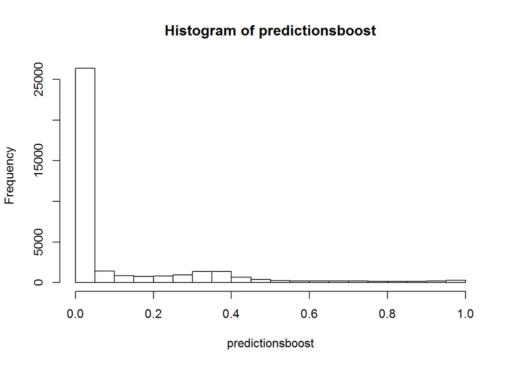

```r
hist(predictionsboost)
```

Note: the outputs have been already ranged from 0 to 1

Since the data set is highly imbalanced as we coul see so far, a threshold other than 0.5 might be useful to make good predictions.Let’s fix it at 0.3 again

```r
predictionsboost<- ifelse(predictionsboost >=0.3,1,0)
```

Let’s evaluate prediction performance

```r
confusionMatrix(predictionsboost,testset1$target)
```

```
## Confusion Matrix and Statistics
##
##           Reference
## Prediction     0     1
##          0 30534   591
##          1  3014  2791
##
##                Accuracy : 0.9024
##                  95% CI : (0.8993, 0.9054)
##     No Information Rate : 0.9084
##     P-Value [Acc > NIR] : 1
##
##                   Kappa : 0.5562
##  Mcnemar's Test P-Value : <2e-16
##
##             Sensitivity : 0.9102
##             Specificity : 0.8253
##          Pos Pred Value : 0.9810
##          Neg Pred Value : 0.4808
##              Prevalence : 0.9084
##          Detection Rate : 0.8268
##    Detection Prevalence : 0.8428
##       Balanced Accuracy : 0.8677
##
##        'Positive' Class : 0
##
```

Not too bad with the accuracy =0.9 and the specificity rate = 0.82

Now, checking model performance by a ROC showing Sensitivity vs. Specificity

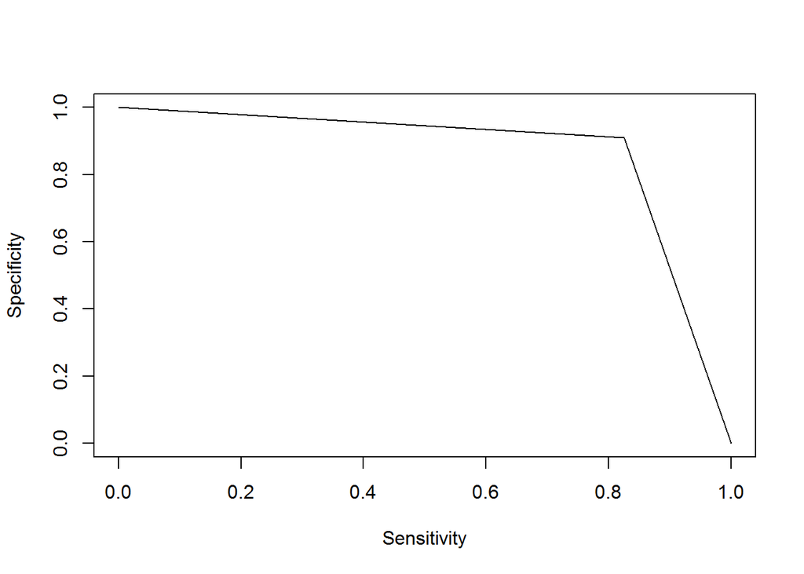

```r
library(ROCR)
performanceGbm<-prediction(predictionsboost,testset1$target)
performanceGbm<-performance(performanceGbm, measure = "spec",x.measure = "sens")
plot(performanceGbm)
```

And taking a look at the AUC metric

```r
performanceGbm<-prediction(predict(modelboost,newdata = testset1[,1:40],n.trees = 197,type = 'response'),testset1$target)
auc<- performance(performanceGbm,measure = "auc")
auc<-auc@y.values[[1]]
auc
```

```
## [1] 0.9538831
```

Good result by AUC = 0.95

- ADAboost

```r
set.seed(0610)
modelAdaboost<-gbm.fit(x=trainset1[,1:40],y=as.vector(trainset1$target),distribution = "adaboost", interaction.depth = 5,n.trees =1000,train.fraction = 0.5,shrinkage = 0.05,n.minobsinnode = 10)
```

```
##      1        0.6303          0.5044     0.0500    0.0181
##      2        0.6136          0.4917     0.0500    0.0168
##      3        0.5980          0.4797     0.0500    0.0157
##      4        0.5833          0.4686     0.0500    0.0148
##      5        0.5697          0.4583     0.0500    0.0136
##      6        0.5570          0.4486     0.0500    0.0128
##      7        0.5448          0.4394     0.0500    0.0121
##      8        0.5337          0.4307     0.0500    0.0111
##      9        0.5235          0.4232     0.0500    0.0102
##     10        0.5137          0.4161     0.0500    0.0097
##     20        0.4454          0.3616     0.0500    0.0048
##     40        0.3909          0.3143     0.0500    0.0017
##     60        0.3712          0.2959     0.0500    0.0011
##     80        0.3599          0.2866     0.0500    0.0004
##    100        0.3506          0.2785     0.0500    0.0003
```

[output cut: 45 more lines]

```r
best.iter <- gbm.perf(modelAdaboost,method="test")
```

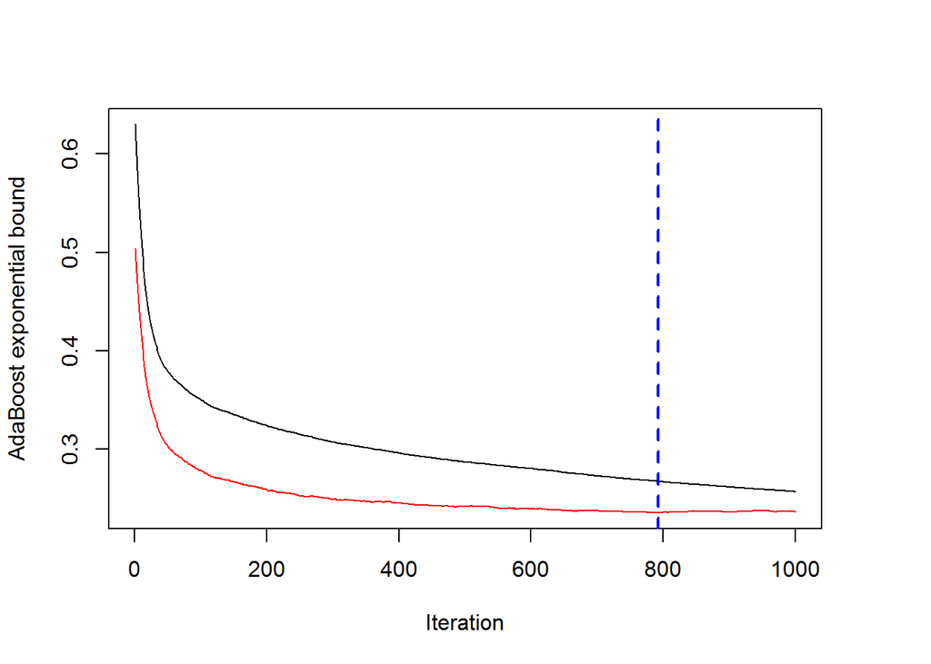

```r
print(best.iter)
```

```
## [1] 793
```

```r
#saveRDS(modelAdaboost,"E:/Project Resil/medi 1/Adaboostgmodel.rds")
```

We now use the boosted model to predict the target in the test set

```r
set.seed(0505)
predictionsAdaboost<- predict(modelAdaboost,newdata = testset1[,1:40],n.trees = 793,type = "response")
# and check the outputs
head(predictionsAdaboost)
```

```
## [1] 0.8237752299 0.0002282595 0.0024731233 0.9989660596 0.0010558039
## [6] 0.0067793936
```

```r
range(predictionsAdaboost)
```

```
## [1] 1.255542e-06 9.999664e-01
```

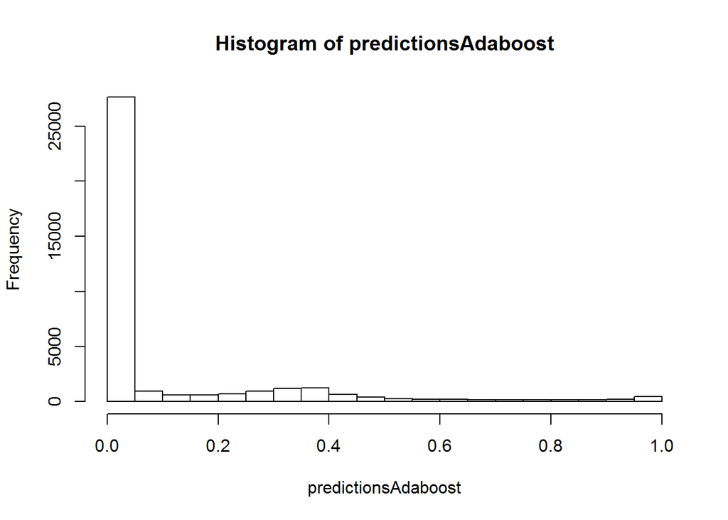

```r
hist(predictionsAdaboost)
```

Using threshold fixed at 0.3

```r
predictionsAdaboost<- ifelse(predictionsAdaboost >=0.3,1,0)
```

Checking prediction performance

```r
confusionMatrix(predictionsAdaboost,testset1$target)
```

```
## Confusion Matrix and Statistics
##
##           Reference
## Prediction     0     1
##          0 30794   615
##          1  2754  2767
##
##                Accuracy : 0.9088
##                  95% CI : (0.9058, 0.9117)
##     No Information Rate : 0.9084
##     P-Value [Acc > NIR] : 0.4117
##
##                   Kappa : 0.5731
##  Mcnemar's Test P-Value : <2e-16
##
##             Sensitivity : 0.9179
##             Specificity : 0.8182
##          Pos Pred Value : 0.9804
##          Neg Pred Value : 0.5012
##              Prevalence : 0.9084
##          Detection Rate : 0.8338
##    Detection Prevalence : 0.8505
##       Balanced Accuracy : 0.8680
##
##        'Positive' Class : 0
##
```

Accuracy = 0.9 and Specificity rate = 0.81, that’s not too bad result

Sensitivity vs. Specificity plot( ADABOOST)

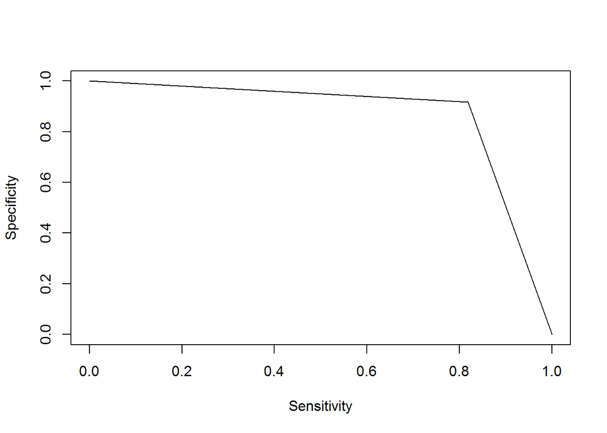

```r
performanceAdb<-prediction(predictionsAdaboost,testset1$target)
performanceAdbROC<-performance(performanceAdb, measure = "spec",x.measure = "sens")
plot(performanceAdbROC)
```

- Gradien Boosting Model ( with caret package)

Fitting the model

```r
gbmmodel<-train(target~., data=trainset1, trControl=trainControl(method="repeatedcv", number=10,repeats=3), method="gbm", verbose=FALSE)
#saveRDS(gbm,"E:/Project Resil/medi 1/GBMcaretmodel.rds")
#GBMcaretmodel<- readRDS("E:/Project Resil/medi 1/GBMcaretmodel.rds")
#preditionsgbm_prob<- predict(gbmmodel, testset1[,1:40],type = "prob")
```

Make predictions

```r
predictionsgbm<- predict(gbmmodel, testset1[,1:40])
confusionMatrix(predictionsgbm,testset1[,41])
```

```
## Confusion Matrix and Statistics
##
##           Reference
## Prediction     0     1
##          0 33354  2190
##          1   194  1192
##
##                Accuracy : 0.9354
##                  95% CI : (0.9329, 0.9379)
##     No Information Rate : 0.9084
##     P-Value [Acc > NIR] : < 2.2e-16
##
##                   Kappa : 0.4719
##  Mcnemar's Test P-Value : < 2.2e-16
##
##             Sensitivity : 0.9942
##             Specificity : 0.3525
##          Pos Pred Value : 0.9384
##          Neg Pred Value : 0.8600
##              Prevalence : 0.9084
##          Detection Rate : 0.9032
##    Detection Prevalence : 0.9625
##       Balanced Accuracy : 0.6733
##
##        'Positive' Class : 0
##
```

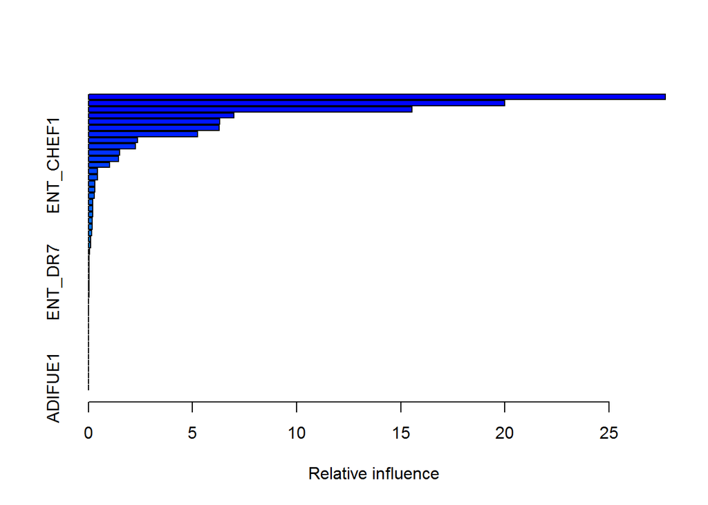

```
##                                                   var      rel.inf
## ADH_DUREE                                   ADH_DUREE 27.714108154
## CGAFM_N                                       CGAFM_N 19.998274233
## ADH_OFC1                                     ADH_OFC1 15.551326193
## AFF_FM_NBSAL                             AFF_FM_NBSAL  6.981334925
## PRESTFM_N                                   PRESTFM_N  6.309192005
## CTX_TOPLJ1                                 CTX_TOPLJ1  6.279604708
## TIERS_TOPCPT1                           TIERS_TOPCPT1  5.248274758
## AFF_FM_TAUXSAL                         AFF_FM_TAUXSAL  2.352301193
## ENT_ANCIENNETE                         ENT_ANCIENNETE  2.267220964
## CTCO_DELAI_TELSORTANT           CTCO_DELAI_TELSORTANT  1.495091719
## CTCO_DELAI_HORSFM                   CTCO_DELAI_HORSFM  1.433078230
## ENT_CHEF1                                   ENT_CHEF1  1.007187777
## CTAD_DELAI_FM                           CTAD_DELAI_FM  0.427389119
## CTAD_NB_TELENTRANT                 CTAD_NB_TELENTRANT  0.422989942
## CTAD_NB_FM                                 CTAD_NB_FM  0.310761667
## CTAD_DELAI_INAFM                     CTAD_DELAI_INAFM  0.300267925
## ENT_TYPGRPEHORS GROUPE         ENT_TYPGRPEHORS GROUPE  0.272431726
## CTAD_DELAI_HORSFM                   CTAD_DELAI_HORSFM  0.217764497
## CTAD_DELAI_TELSORTANT           CTAD_DELAI_TELSORTANT  0.216656361
## CTCO_NB_TELENTRANT                 CTCO_NB_TELENTRANT  0.206204813
## ENT_TOPMAIL1                             ENT_TOPMAIL1  0.185953743
## CTX_TOPRJ1                                 CTX_TOPRJ1  0.185707042
## CTCO_DELAI_TELENTRANT           CTCO_DELAI_TELENTRANT  0.142088615
## ENT_TOPTELPORT1                       ENT_TOPTELPORT1  0.114718757
## CTAD_NB_INAFM                           CTAD_NB_INAFM  0.094589612
## CTCO_DELAI_VISITE                   CTCO_DELAI_VISITE  0.052822748
## ENT_TYPGRPEGROUPE REGIONAL ENT_TYPGRPEGROUPE REGIONAL  0.040646111
## CTAD_DELAI_INA                         CTAD_DELAI_INA  0.038835006
## CTCO_NB_HORSFM                         CTCO_NB_HORSFM  0.027354430
## ENT_DR9                                       ENT_DR9  0.023002226
## ENT_DR7                                       ENT_DR7  0.022731934
## CTCO_NB_TELSORTANT                 CTCO_NB_TELSORTANT  0.020688554
## CTAD_NB_HORSFM                         CTAD_NB_HORSFM  0.018917621
## CTAD_NB_TELSORTANT                 CTAD_NB_TELSORTANT  0.010495294
## CTAD_NB_INA                               CTAD_NB_INA  0.009987397
## ENT_DR2                                       ENT_DR2  0.000000000
## ENT_DR3                                       ENT_DR3  0.000000000
## ENT_DR4                                       ENT_DR4  0.000000000
## ENT_DR5                                       ENT_DR5  0.000000000
## ENT_DR6                                       ENT_DR6  0.000000000
## ENT_DR8                                       ENT_DR8  0.000000000
## CTCO_NB_FM                                 CTCO_NB_FM  0.000000000
## CTCO_DELAI_FM                           CTCO_DELAI_FM  0.000000000
## CTCO_NB_VISITE                         CTCO_NB_VISITE  0.000000000
## CTCO_NB_SIM                               CTCO_NB_SIM  0.000000000
## CTCO_DELAI_SIM                         CTCO_DELAI_SIM  0.000000000
## AGE_MOYEN                                   AGE_MOYEN  0.000000000
## ADIFUE1                                       ADIFUE1  0.000000000
```

```r
summary(gbmmodel)
```

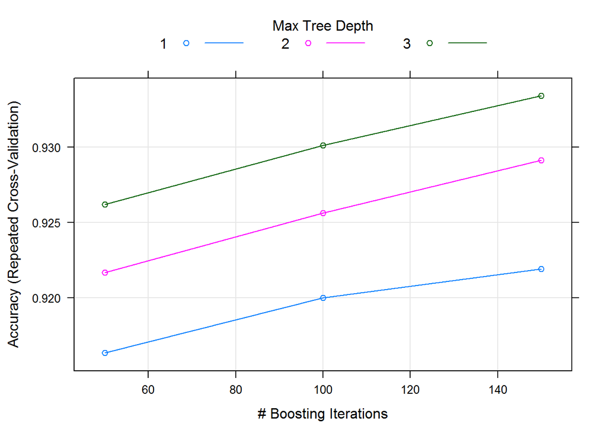

```r
plot(gbmmodel)
```

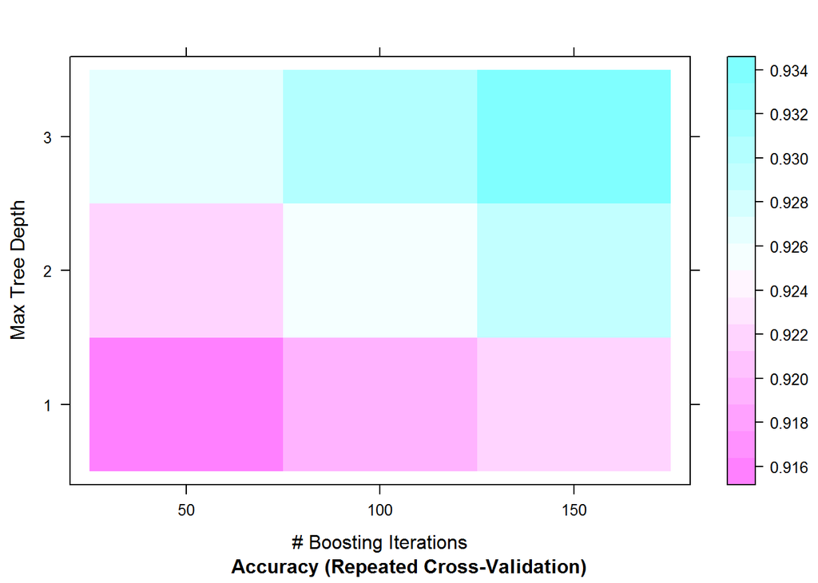

```r
plot(gbmmodel,plotType = "level")
```

Make predictions by tuning the threshold at 0.3

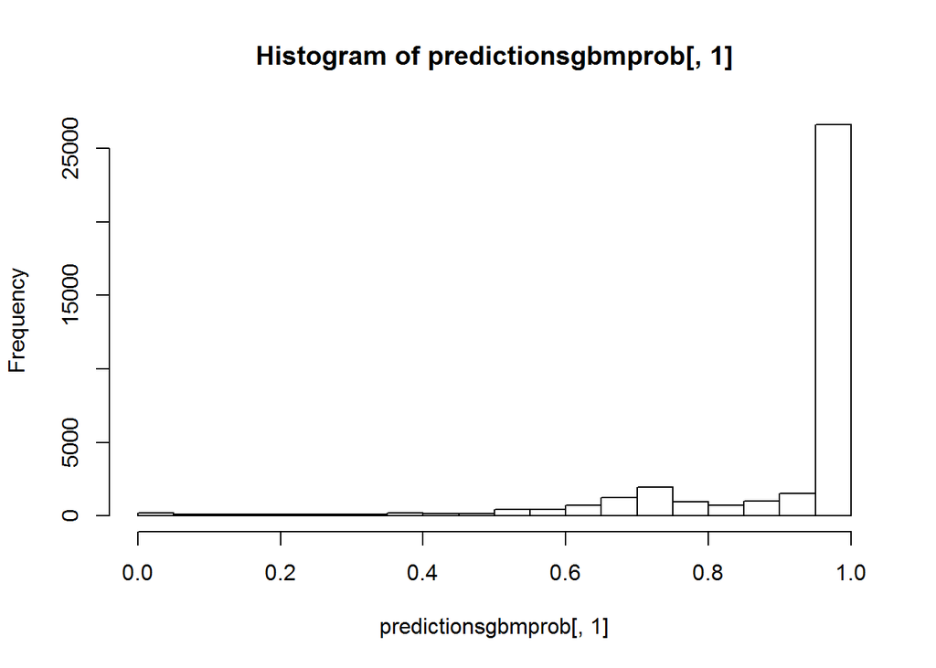

```r
predictionsgbmprob <- predict(gbmmodel, testset1[,1:40], type="prob")
hist(predictionsgbmprob[,1])
```

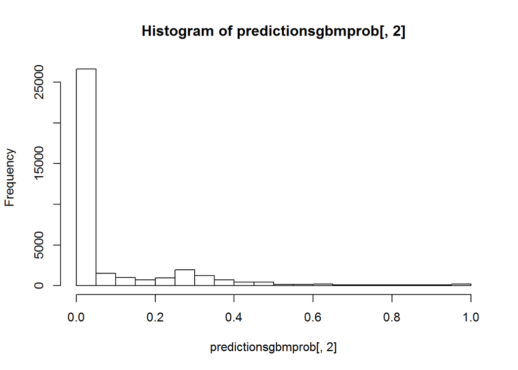

```r
hist(predictionsgbmprob[,2])
```

```r
predictionsgbmprob<- ifelse(predictionsgbmprob$`1` >=0.3,1,0)
confusionMatrix(predictionsgbmprob,testset1$target)
```

```
## Confusion Matrix and Statistics
##
##           Reference
## Prediction     0     1
##          0 31655  1105
##          1  1893  2277
##
##                Accuracy : 0.9188
##                  95% CI : (0.916, 0.9216)
##     No Information Rate : 0.9084
##     P-Value [Acc > NIR] : 9.608e-13
##
##                   Kappa : 0.5584
##  Mcnemar's Test P-Value : < 2.2e-16
##
##             Sensitivity : 0.9436
##             Specificity : 0.6733
##          Pos Pred Value : 0.9663
##          Neg Pred Value : 0.5460
##              Prevalence : 0.9084
##          Detection Rate : 0.8572
##    Detection Prevalence : 0.8871
##       Balanced Accuracy : 0.8084
##
##        'Positive' Class : 0
##
```

Plotting the curve showing Sensitivity vs. Specificity

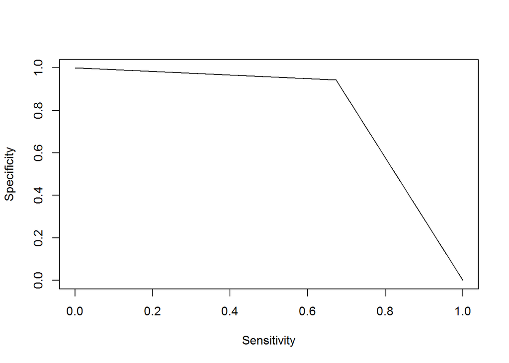

```r
performanceGbmc<-prediction(predictionsgbmprob,testset1$target)
performanceGbmcROC<-performance(performanceGbmc, measure = "spec",x.measure = "sens")
plot(performanceGbmcROC)
```

# Regression Logistic

In this part, I will use a binomial logistic regression since the variable to predict is binary ( you should remember we have used a mutinomial logistic model in the part 1)

Let’s fit the logistic model

```r
set.seed(3004)
modelLog <- glm(target ~.,family=binomial(link='logit'),data=trainset1)
summary(modelLog)
```

```
##
## Call:
## glm(formula = target ~ ., family = binomial(link = "logit"),
##     data = trainset1)
##
## Deviance Residuals:
##     Min       1Q   Median       3Q      Max
## -8.4904  -0.3197  -0.1204  -0.0427   8.4904
##
## Coefficients:
##                              Estimate Std. Error z value Pr(>|z|)
## (Intercept)                 2.019e+00  1.155e-01  17.485  < 2e-16 ***
## ENT_TYPGRPEGROUPE REGIONAL  6.739e-02  7.696e-02   0.876 0.381195
## ENT_TYPGRPEHORS GROUPE     -2.377e-01  4.886e-02  -4.866 1.14e-06 ***
## ENT_DR2                    -8.259e-02  5.908e-02  -1.398 0.162145
## ENT_DR3                    -4.360e-02  3.920e-02  -1.112 0.266096
## ENT_DR4                    -2.015e-01  4.105e-02  -4.908 9.20e-07 ***
## ENT_DR5                    -2.380e-01  4.567e-02  -5.212 1.87e-07 ***
## ENT_DR6                    -7.623e-02  3.903e-02  -1.953 0.050788 .
## ENT_DR7                    -4.201e-01  4.832e-02  -8.694  < 2e-16 ***
## ENT_DR8                    -2.558e-01  4.305e-02  -5.941 2.84e-09 ***
## ENT_DR9                     8.208e-02  4.766e-02   1.722 0.085031 .
## ENT_ANCIENNETE              5.439e-05  3.971e-06  13.696  < 2e-16 ***
## ENT_TOPTELPORT1            -1.586e-01  2.723e-02  -5.824 5.76e-09 ***
## ENT_TOPMAIL1               -3.588e-03  2.842e-02  -0.126 0.899552
## ENT_CHEF1                  -4.789e-01  2.636e-02 -18.163  < 2e-16 ***
## TIERS_TOPCPT1              -2.783e+00  7.050e-02 -39.469  < 2e-16 ***
## CTAD_NB_FM                  7.261e-01  3.997e-02  18.164  < 2e-16 ***
## CTAD_DELAI_FM              -2.785e-03  5.822e-04  -4.784 1.72e-06 ***
## CTCO_NB_FM                  6.577e-02  1.486e-02   4.425 9.65e-06 ***
## CTCO_DELAI_FM              -8.509e-04  4.693e-04  -1.813 0.069840 .
## CTAD_NB_HORSFM             -3.508e-02  4.410e-03  -7.955 1.80e-15 ***
## CTAD_DELAI_HORSFM          -1.427e-03  3.223e-04  -4.426 9.60e-06 ***
## CTCO_NB_HORSFM             -1.822e-01  1.281e-02 -14.228  < 2e-16 ***
## CTCO_DELAI_HORSFM          -3.343e-03  3.546e-04  -9.428  < 2e-16 ***
## CTAD_NB_INA                 9.873e-02  3.949e-02   2.500 0.012417 *
## CTAD_DELAI_INA             -7.592e-04  3.585e-04  -2.117 0.034229 *
## CTAD_NB_INAFM               1.032e+00  9.894e-02  10.430  < 2e-16 ***
## CTAD_DELAI_INAFM           -6.594e-03  9.549e-04  -6.906 5.00e-12 ***
## CTCO_NB_VISITE              6.982e-02  2.008e-02   3.476 0.000508 ***
```

[output cut: 15 more lines]

```
## ADH_DUREE                   2.076e-05  5.217e-06   3.980 6.89e-05 ***
## ADH_OFC1                   -2.684e+00  6.254e-02 -42.906  < 2e-16 ***
## AFF_FM_NBSAL                1.640e-01  4.452e-03  36.847  < 2e-16 ***
## AFF_FM_TAUXSAL             -1.292e+00  3.218e-02 -40.140  < 2e-16 ***
## ADIFUE1                    -1.290e+00  8.979e-02 -14.367  < 2e-16 ***
## ---
## Signif. codes:  0 '***' 0.001 '**' 0.01 '*' 0.05 '.' 0.1 ' ' 1
##
## (Dispersion parameter for binomial family taken to be 1)
##
##     Null deviance: 90466  on 147721  degrees of freedom
## Residual deviance: 55874  on 147673  degrees of freedom
## AIC: 55972
##
## Number of Fisher Scoring iterations: 11
```

```r
#saveRDS(modelLog,"E:/Project Resil/medi 1/Logmodel.rds")
```

```r
# checking reference value of the target
contrasts(df2$target)
```

```
##   1
## 0 0
## 1 1
```

In other hand , the binomial logistic regression deal directly with categorical variables so that those variables are dummyfied for the model as you can see for example ENT_DR1 has been used as reference for the ENT_DR variable Lets’check it

```r
contrasts(df2$ENT_DR)
```

```
##   2 3 4 5 6 7 8 9
## 1 0 0 0 0 0 0 0 0
## 2 1 0 0 0 0 0 0 0
## 3 0 1 0 0 0 0 0 0
## 4 0 0 1 0 0 0 0 0
## 5 0 0 0 1 0 0 0 0
## 6 0 0 0 0 1 0 0 0
## 7 0 0 0 0 0 1 0 0
## 8 0 0 0 0 0 0 1 0
## 9 0 0 0 0 0 0 0 1
```

ANOVA analysis

```r
anova(modelLog, test = "Chisq")
```

```
## Analysis of Deviance Table
##
## Model: binomial, link: logit
##
## Response: target
##
## Terms added sequentially (first to last)
##
##
##                       Df Deviance Resid. Df Resid. Dev  Pr(>Chi)
## NULL                                 147721      90466
## ENT_TYPGRPE            2    888.0    147719      89578 < 2.2e-16 ***
## ENT_DR                 8    271.9    147711      89306 < 2.2e-16 ***
## ENT_ANCIENNETE         1    837.3    147710      88469 < 2.2e-16 ***
## ENT_TOPTELPORT         1   2072.2    147709      86397 < 2.2e-16 ***
## ENT_TOPMAIL            1   3545.4    147708      82851 < 2.2e-16 ***
## ENT_CHEF               1    825.3    147707      82026 < 2.2e-16 ***
## TIERS_TOPCPT           1   2926.1    147706      79100 < 2.2e-16 ***
## CTAD_NB_FM             1      0.2    147705      79100  0.637019
## CTAD_DELAI_FM          1    601.6    147704      78498 < 2.2e-16 ***
## CTCO_NB_FM             1    174.0    147703      78324 < 2.2e-16 ***
## CTCO_DELAI_FM          1    325.7    147702      77998 < 2.2e-16 ***
## CTAD_NB_HORSFM         1    192.4    147701      77806 < 2.2e-16 ***
## CTAD_DELAI_HORSFM      1      5.2    147700      77801  0.022582 *
## CTCO_NB_HORSFM         1    706.2    147699      77094 < 2.2e-16 ***
## CTCO_DELAI_HORSFM      1     20.0    147698      77074 7.813e-06 ***
## CTAD_NB_INA            1      1.1    147697      77073  0.289860
## CTAD_DELAI_INA         1    107.4    147696      76966 < 2.2e-16 ***
## CTAD_NB_INAFM          1     72.7    147695      76893 < 2.2e-16 ***
## CTAD_DELAI_INAFM       1    132.2    147694      76761 < 2.2e-16 ***
## CTCO_NB_VISITE         1    949.1    147693      75812 < 2.2e-16 ***
## CTCO_DELAI_VISITE      1    796.4    147692      75016 < 2.2e-16 ***
## CTCO_NB_SIM            1      7.2    147691      75008  0.007151 **
## CTCO_DELAI_SIM         1      9.0    147690      74999  0.002686 **
## CTAD_NB_TELENTRANT     1     49.2    147689      74950 2.255e-12 ***
## CTAD_NB_TELSORTANT     1      8.4    147688      74942  0.003810 **
## CTAD_DELAI_TELSORTANT  1    612.3    147687      74329 < 2.2e-16 ***
## CTCO_NB_TELENTRANT     1    135.0    147686      74194 < 2.2e-16 ***
## CTCO_DELAI_TELENTRANT  1     67.9    147685      74126 < 2.2e-16 ***
## CTCO_NB_TELSORTANT     1   1788.9    147684      72337 < 2.2e-16 ***
## CTCO_DELAI_TELSORTANT  1   1174.1    147683      71163 < 2.2e-16 ***
## CTX_TOPLJ              1   2884.2    147682      68279 < 2.2e-16 ***
## CTX_TOPRJ              1     92.7    147681      68187 < 2.2e-16 ***
## PRESTFM_N              1   3204.2    147680      64982 < 2.2e-16 ***
## CGAFM_N                1   2104.4    147679      62878 < 2.2e-16 ***
## AGE_MOYEN              1      1.4    147678      62877  0.231314
## ADH_DUREE              1    411.2    147677      62465 < 2.2e-16 ***
## ADH_OFC                1   3615.5    147676      58850 < 2.2e-16 ***
## AFF_FM_NBSAL           1   1114.6    147675      57735 < 2.2e-16 ***
## AFF_FM_TAUXSAL         1   1594.0    147674      56141 < 2.2e-16 ***
## ADIFUE                 1    266.9    147673      55874 < 2.2e-16 ***
## ---
## Signif. codes:  0 '***' 0.001 '**' 0.01 '*' 0.05 '.' 0.1 ' ' 1
```

```r
# or see by ordering the results
drop1(modelLog,test = "Chisq")
```

```
## Single term deletions
##
## Model:
## target ~ ENT_TYPGRPE + ENT_DR + ENT_ANCIENNETE + ENT_TOPTELPORT +
##     ENT_TOPMAIL + ENT_CHEF + TIERS_TOPCPT + CTAD_NB_FM + CTAD_DELAI_FM +
##     CTCO_NB_FM + CTCO_DELAI_FM + CTAD_NB_HORSFM + CTAD_DELAI_HORSFM +
##     CTCO_NB_HORSFM + CTCO_DELAI_HORSFM + CTAD_NB_INA + CTAD_DELAI_INA +
##     CTAD_NB_INAFM + CTAD_DELAI_INAFM + CTCO_NB_VISITE + CTCO_DELAI_VISITE +
##     CTCO_NB_SIM + CTCO_DELAI_SIM + CTAD_NB_TELENTRANT + CTAD_NB_TELSORTANT +
##     CTAD_DELAI_TELSORTANT + CTCO_NB_TELENTRANT + CTCO_DELAI_TELENTRANT +
##     CTCO_NB_TELSORTANT + CTCO_DELAI_TELSORTANT + CTX_TOPLJ +
##     CTX_TOPRJ + PRESTFM_N + CGAFM_N + AGE_MOYEN + ADH_DUREE +
##     ADH_OFC + AFF_FM_NBSAL + AFF_FM_TAUXSAL + ADIFUE
##                       Df Deviance   AIC    LRT  Pr(>Chi)
## <none>                      55874 55972
## ENT_TYPGRPE            2    55913 56007   38.9 3.495e-09 ***
## ENT_DR                 8    56028 56110  153.6 < 2.2e-16 ***
## ENT_ANCIENNETE         1    56062 56158  187.3 < 2.2e-16 ***
## ENT_TOPTELPORT         1    55908 56004   33.6 6.821e-09 ***
## ENT_TOPMAIL            1    55874 55970    0.0 1.0000000
## ENT_CHEF               1    56205 56301  330.9 < 2.2e-16 ***
## TIERS_TOPCPT           1    57680 57776 1806.0 < 2.2e-16 ***
## CTAD_NB_FM             1    56174 56270  299.7 < 2.2e-16 ***
## CTAD_DELAI_FM          1    55898 55994   23.9 1.010e-06 ***
## CTCO_NB_FM             1    55890 55986   15.5 8.261e-05 ***
## CTCO_DELAI_FM          1    55878 55974    3.1 0.0773773 .
## CTAD_NB_HORSFM         1    55949 56045   75.0 < 2.2e-16 ***
## CTAD_DELAI_HORSFM      1    55895 55991   20.5 5.850e-06 ***
## CTCO_NB_HORSFM         1    56132 56228  257.4 < 2.2e-16 ***
## CTCO_DELAI_HORSFM      1    55978 56074  103.9 < 2.2e-16 ***
## CTAD_NB_INA            1    55881 55977    6.5 0.0106102 *
## CTAD_DELAI_INA         1    55879 55975    4.5 0.0333427 *
## CTAD_NB_INAFM          1    55978 56074  104.0 < 2.2e-16 ***
## CTAD_DELAI_INAFM       1    55927 56023   53.1 3.220e-13 ***
## CTCO_NB_VISITE         1    55886 55982   12.0 0.0005394 ***
## CTCO_DELAI_VISITE      1    56002 56098  127.4 < 2.2e-16 ***
## CTCO_NB_SIM            1    55878 55974    3.6 0.0592358 .
## CTCO_DELAI_SIM         1    55875 55971    0.6 0.4452583
## CTAD_NB_TELENTRANT     1    55961 56057   86.6 < 2.2e-16 ***
## CTAD_NB_TELSORTANT     1    56063 56159  188.8 < 2.2e-16 ***
## CTAD_DELAI_TELSORTANT  1    56042 56138  167.2 < 2.2e-16 ***
## CTCO_NB_TELENTRANT     1    55988 56084  114.0 < 2.2e-16 ***
## CTCO_DELAI_TELENTRANT  1    55878 55974    3.1 0.0771895 .
## CTCO_NB_TELSORTANT     1    55908 56004   33.6 6.699e-09 ***
## CTCO_DELAI_TELSORTANT  1    56239 56335  364.8 < 2.2e-16 ***
## CTX_TOPLJ              1    57638 57734 1763.6 < 2.2e-16 ***
## CTX_TOPRJ              1    56001 56097  126.4 < 2.2e-16 ***
## PRESTFM_N              1    57684 57780 1810.0 < 2.2e-16 ***
## CGAFM_N                1    58309 58405 2434.5 < 2.2e-16 ***
## AGE_MOYEN              1    55874 55970    0.0 1.0000000
## ADH_DUREE              1    55891 55987   16.2 5.706e-05 ***
## ADH_OFC                1    59135 59231 3261.0 < 2.2e-16 ***
## AFF_FM_NBSAL           1    58050 58146 2175.9 < 2.2e-16 ***
## AFF_FM_TAUXSAL         1    57454 57550 1579.9 < 2.2e-16 ***
## ADIFUE                 1    56141 56237  266.9 < 2.2e-16 ***
## ---
## Signif. codes:  0 '***' 0.001 '**' 0.01 '*' 0.05 '.' 0.1 ' ' 1
```

```r
# see Mc Faden indicator
library(pscl)
pR2(modelLog)
```

```
##           llh       llhNull            G2      McFadden          r2ML
## -2.793721e+04 -4.523297e+04  3.459153e+04  3.823707e-01  2.087698e-01
##          r2CU
##  4.558739e-01
```

Let’s make predictions with Logistic model

```r
# Predictions Logistic Model/ with thresold=0.5 probability : if P(y=1/X)>0.5 ( decision boundary); type= reponse gives probabilities P(y=1), making type= 'classe' gives 0 or 1
predictionLog<- predict(modelLog, newdata = testset1[,1:40],type = "response")
head(predictionLog,2)
```

```
##          5          6
## 0.43911005 0.01865389
```

Creating the decision boundary =0.5; however this threshold can be ajusted

```r
resultLog<- ifelse(predictionLog>0.5,1,0)
```

Checking the model accuracy

```r
misClassiferror<- mean(resultLog!=testset1$target)
print(paste('Accuracy',1-misClassiferror))
```

```
## [1] "Accuracy 0.923693474140265"
```

```r
conf.matrix <- table(resultLog,testset1$target)
rownames(conf.matrix) <- paste("Pred", rownames(conf.matrix), sep = "=")
colnames(conf.matrix) <- paste("Obs", colnames(conf.matrix), sep = "=")
print(conf.matrix)
```

```
##
## resultLog Obs=0 Obs=1
##    Pred=0 33243  2513
##    Pred=1   305   869
```

```r
confusionMatrix(resultLog,testset1$target)
```

```
## Confusion Matrix and Statistics
##
##           Reference
## Prediction     0     1
##          0 33243  2513
##          1   305   869
##
##                Accuracy : 0.9237
##                  95% CI : (0.9209, 0.9264)
##     No Information Rate : 0.9084
##     P-Value [Acc > NIR] : < 2.2e-16
##
##                   Kappa : 0.3508
##  Mcnemar's Test P-Value : < 2.2e-16
##
##             Sensitivity : 0.9909
##             Specificity : 0.2569
##          Pos Pred Value : 0.9297
##          Neg Pred Value : 0.7402
##              Prevalence : 0.9084
##          Detection Rate : 0.9002
##    Detection Prevalence : 0.9682
##       Balanced Accuracy : 0.6239
##
##        'Positive' Class : 0
##
```

Note: poor specificity rate

Making ROC

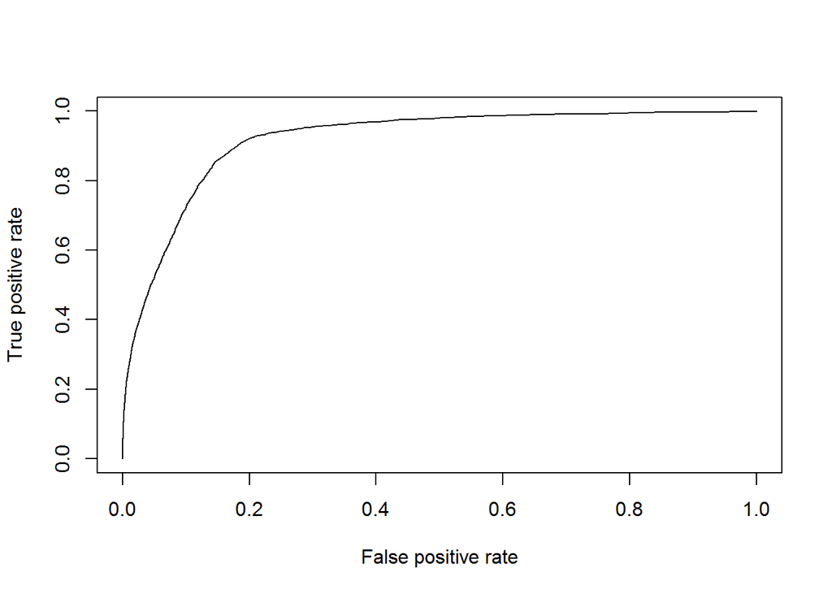

```r
library(ROCR)
performanceLog<-prediction(predict(modelLog, newdata = testset1[,1:40],type = "response"),testset1$target)
performanceLogplot<-performance(performanceLog, measure = "tpr",x.measure = "fpr")
plot(performanceLogplot)
```

Compute the AUC/ Note: a good predictive ability should have an AUC closer to 1 than to 0.5

```r
auc<- performance(performanceLog,measure = "auc")
auc<-auc@y.values[[1]]
auc
```

```
## [1] 0.9180204
```

Trying to improve the specificity score by tuning the threshold( to increase the True Positive for the class 1 = resilie)

```r
# fix the threshold=0.1, since the data is high imbalanced
resultLog1<- ifelse(predictionLog>0.3,1,0)
misClassiferror1<- mean(resultLog1!=testset1$target)
print(paste('Accuracy',1-misClassiferror1))
```

```
## [1] "Accuracy 0.9053885729759"
```

```r
confusionMatrix(resultLog1,testset1$target)
```

```
## Confusion Matrix and Statistics
##
##           Reference
## Prediction     0     1
##          0 31524  1470
##          1  2024  1912
##
##                Accuracy : 0.9054
##                  95% CI : (0.9024, 0.9084)
##     No Information Rate : 0.9084
##     P-Value [Acc > NIR] : 0.9784
##
##                   Kappa : 0.4704
##  Mcnemar's Test P-Value : <2e-16
##
##             Sensitivity : 0.9397
##             Specificity : 0.5653
##          Pos Pred Value : 0.9554
##          Neg Pred Value : 0.4858
##              Prevalence : 0.9084
##          Detection Rate : 0.8536
##    Detection Prevalence : 0.8934
##       Balanced Accuracy : 0.7525
##
##        'Positive' Class : 0
##
```

Sensitivity vs. Specificity Plot

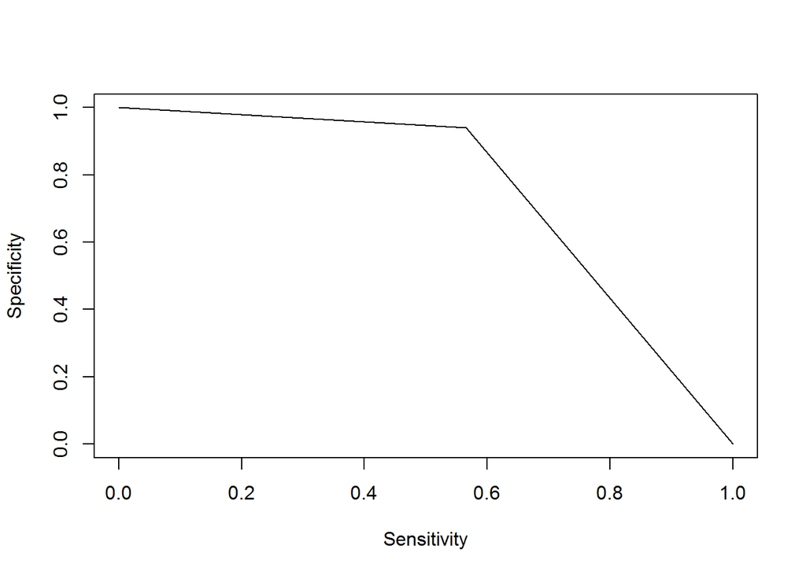

```r
performanceLog<-prediction(resultLog1,testset1$target)
performanceLogROC<-performance(performanceLog, measure = "spec",x.measure = "sens")
plot(performanceLogROC)
```

# Random Over Sampling (ROSE package)

We have used technique tunning thresholds explicity so that the resulting preditions give more accurate specificity rate.

We now would like to try the ROSE ( Random Over Sampling Examples ) package for making predictions in artificial data generated by this method.

Loading the package and resampling the data

```r
library(ROSE)
trainset.rose<-ROSE(target~ .,data = trainset1,seed=3)$data
testset.rose<- ROSE(target~., data = testset1,seed = 1)$data
```

Making some checks

```r
dim(trainset.rose)
```

```
## [1] 147722     41
```

```r
dim(testset.rose)
```

```
## [1] 36930    41
```

```r
table(trainset.rose$target)
```

```
##
##     0     1
## 73826 73896
```

```r
table(testset.rose$target)
```

```
##
##     0     1
## 18539 18391
```

Fiting the model by using Naive Bayes algorithm

```r
set.seed(0505)
modeltNBrose<-train(target~., data=trainset.rose, trControl=train_control, method="nb")

print(modeltNBrose)
```

```
## Naive Bayes
##
## 147722 samples
##     40 predictor
##      2 classes: '0', '1'
##
## No pre-processing
## Resampling: Cross-Validated (10 fold, repeated 3 times)
## Summary of sample sizes: 132949, 132950, 132951, 132950, 132949, 132951, ...
## Resampling results across tuning parameters:
##
##   usekernel  Accuracy   Kappa
##   FALSE      0.9043700  0.8087407
##    TRUE      0.9615562  0.9231145
##
## Tuning parameter 'fL' was held constant at a value of 0
## Tuning
##  parameter 'adjust' was held constant at a value of 1
## Accuracy was used to select the optimal model using  the largest value.
## The final values used for the model were fL = 0, usekernel = TRUE
##  and adjust = 1.
```

```r
#saveRDS(modeltNBrose,"E:/Project Resil/medi 1/NBRosemodel.rds")
```

Making predictions

```r
#make predictions
predictions.rose <- predict(modeltNBrose, testset.rose[,1:40])
```

And checking prediction results

```r
confusionMatrix(predictions.rose,testset.rose[,41])
```

```
## Confusion Matrix and Statistics
##
##           Reference
## Prediction     0     1
##          0 18434  8203
##          1   105 10188
##
##                Accuracy : 0.775
##                  95% CI : (0.7707, 0.7793)
##     No Information Rate : 0.502
##     P-Value [Acc > NIR] : < 2.2e-16
##
##                   Kappa : 0.5493
##  Mcnemar's Test P-Value : < 2.2e-16
##
##             Sensitivity : 0.9943
##             Specificity : 0.5540
##          Pos Pred Value : 0.6920
##          Neg Pred Value : 0.9898
##              Prevalence : 0.5020
##          Detection Rate : 0.4992
##    Detection Prevalence : 0.7213
##       Balanced Accuracy : 0.7742
##
##        'Positive' Class : 0
##
```

# Model Selection

We will evaluate the performance of models throught 3 metrics: Accuracy, Sensitivity and Specificity.

- Sensitivity : the fraction of the non cancelled contracts correctly identified; True positive ( class 0)/ (True positive + False negative)
- Specificity: the fraction of the cancelled contracts correctly identified ;True negative ( class 1)/ True negative+ Fals positive; This metric is important for us.
- Accuracy: the fraction of all contracts correctly identified

```r
Tree<-confusionMatrix(predictionstreeprob,y_test)
Bagging<-confusionMatrix(predictions.bagprob,testset1$target)
RF<-confusionMatrix(predictionsRFprob,testset1$target)
Gbm<-confusionMatrix(predictionsboost,testset1$target)
Adaboost<-confusionMatrix(predictionsAdaboost,testset1$target)
Gbmcaret<-confusionMatrix(predictionsgbmprob,testset1$target)
Rose<-confusionMatrix(predictions.rose,testset.rose[,41])
Logistic<- confusionMatrix(resultLog1,testset1$target)
```

Let’s check the performance of each model by 3 following metrics: Accuracy, Sensitivity and Specificity.

```r
md<- data.frame(Tree_model= c(Tree$overall[1],Tree$byClass[1],Tree$byClass[2]),
                Bagging=c(Bagging$overall[1],Bagging$byClass[1],Bagging$byClass[2]),
                Random_Forest=c(RF$overall[1],RF$byClass[1],RF$byClass[2]),
                Gr.Boosting = c(Gbm$overall[1],Gbm$byClass[1],Gbm$byClass[2]),
                Adaboost= c(Adaboost$overall[1], Adaboost$byClass[1],Adaboost$byClass[2]),
                G.Boosting_car=c(Gbmcaret$overall[1],Gbmcaret$byClass[1],Gbmcaret$byClass[2]),
                Rose_N.Bayes=c(Rose$overall[1],Rose$byClass[1],Rose$byClass[2]),
                Logistic_Reg= c(Logistic$overall[1],Logistic$byClass[1],Logistic$byClass[2]))

md<-data.frame(t(md))

print(md)
```

```
##                 Accuracy Sensitivity Specificity
## Tree_model     0.9272136   0.9601765   0.6002365
## Bagging        0.9410777   0.9663467   0.6904199
## Random_Forest  0.9408069   0.9742757   0.6088114
## Gr.Boosting    0.9023829   0.9101586   0.8252513
## Adaboost       0.9087734   0.9179087   0.8181549
## G.Boosting_car 0.9188194   0.9435734   0.6732703
## Rose_N.Bayes   0.7750338   0.9943363   0.5539666
## Logistic_Reg   0.9053886   0.9396685   0.5653459
```

And let’s take a look at these accuracy metrics by using plot 3D

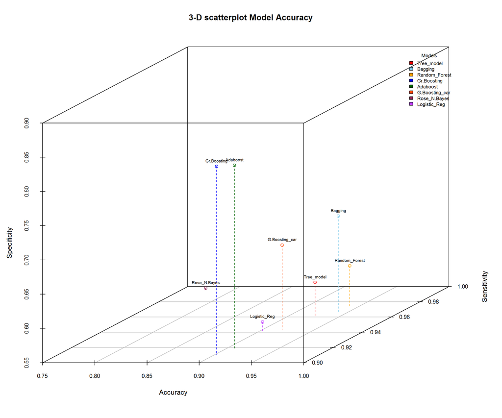

```r
library(scatterplot3d)
colours<-c('red','skyblue','orange','blue','darkgreen','orangered','violetred 4','darkorchid1')
md$colours<-colours
with(md, {s3d<- scatterplot3d(Accuracy,Sensitivity,Specificity,color = colours,type='h',lty.hplot = 2,main = '3-D scatterplot Model Accuracy',
xlab = 'Accuracy',ylab='Sensitivity',zlab='Specificity')
s3d.coords<-s3d$xyz.convert( Accuracy,Sensitivity,Specificity)
text(s3d.coords$x,s3d.coords$y,labels = row.names(md),pos=3,cex=.6)
legend("topright",inset=.05,bty = "n",cex=.7,title = "Models",c('Tree_model','Bagging', 'Random_Forest','Gr.Boosting','Adaboost','G.Boosting_car','Rose_N.Bayes','Logistic_Reg'),
fill = c('red','skyblue','orange','blue','darkgreen','orangered','violetred 4','darkorchid1'))})
```

The figures show Gradien Boosting and Adaboost are the best models according to the selected metrics.

# End Note

In this section, I’ve pursued our organization ’s Data project by trying to apply somme Data Analyse and Machine Learning techniques to the original data set.

One of the aims was to detect more relevant informations which could be useful for our business understanding and strategy,throught the data we had selected.

The fist attemps with somme Machine Learning methods could allow us to put predictive approache into our data and get somme interesting and informative result.

However, this Data project continues and we will be kepping it together maybe until the end of 2016 and the deployment of a final model.

We also will able to test the performance of models in a data base that will be collected for a more recent period.

Finnaly, our next multidisciplinary meeting should able us to make the best use of Data science approaches to the business aims that the project imposes.